# CUE Summary

Mustafa

Downloading Summary Carbon Use Efficiency Unconstrained CUE Phylogenetic Analysis Constrained CUE Uptake Kinetics Effect Sizes

# 1

# **Downloading Summary**

The DOE knowledgebase (kBASE) was searched for genomes from six major phyla found in soil microbial communities. A total of 24,268 genomes were found to correspond to the six major phyla. Results were trimmed to eliminate duplicates within a given genus, resulting in 1,082 unique genera. These genera were searched in the primary literature to determine habitat preference, and eliminate non-soil bacterial species. Ultimately, 231 species were selected for analysis.

|  | Genomes | Genera | Selections |
| --- | --- | --- | --- |
| Alpha | 1709 | 197 | 32 |
| Beta | 1092 | 114 | 30 |
| Gamma | 7731 | 240 | 19 |
| Delta | 185 | 56 | 10 |
| Actino | 4055 | 191 | 25 |
| Acido | 25 | 12 | 25 |
| Firm | 8668 | 233 | 25 |
| Verr | 36 | 9 | 36 |
| Plancto | 29 | 12 | 29 |

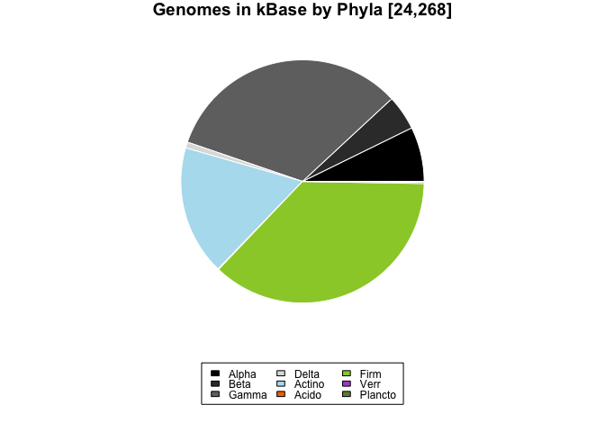

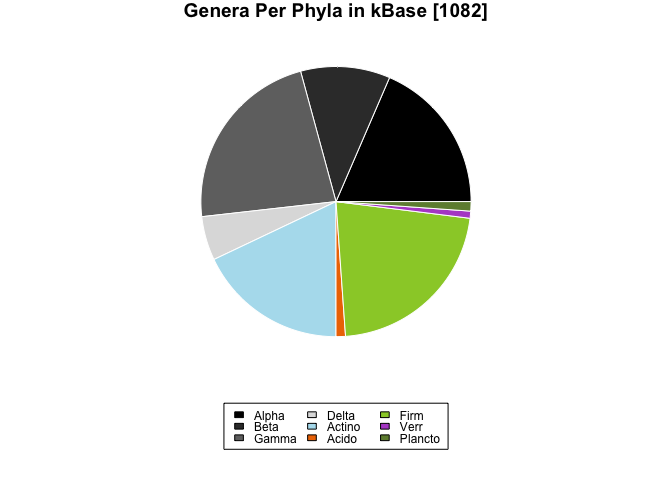

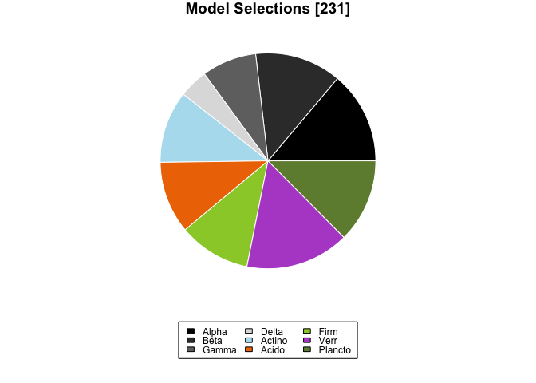

A database of exchange reactions was built to represent the full range of metabolites possible for uptake across all models. Number of C atoms and Gibbs free energy were noted for each metabolite. Models were compared for similarity of exchange reaction identity using MDS ordination.

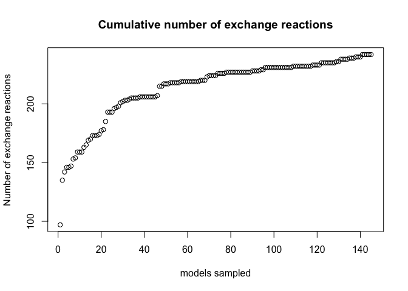

```
## ... procrustes: rmse 0.01921493  max resid 0.1135103
## ... procrustes: rmse 0.01205787  max resid 0.1355231
```

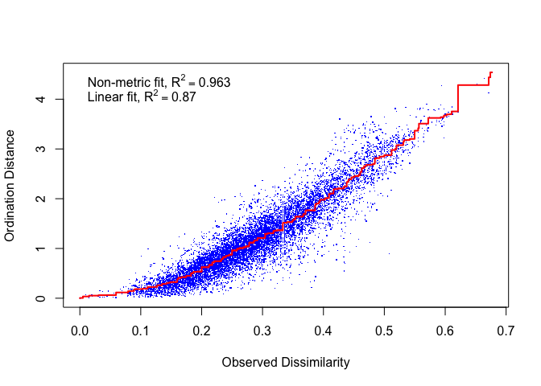

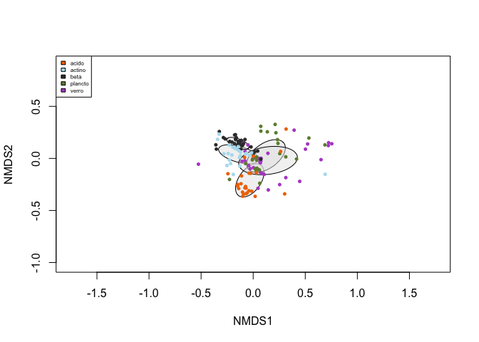

# 2

# **CARBON USE EFFICIENCY**

**CUE=(Net C Uptake - Respiration)/(Total C Uptake)**

Carbon use efficiency was explored under two scenarios. (1) Unconstrained CUE was calculated by allowing a model to utilize all exchange reactions present, and (2) Constrained CUE was calculated by limiting the availability of a single constraining C-containing metabolite while leaving all other unconstrained.

# 2a

## **UNCONSTRAINED CUE**

Unconstrained CUE ranged from 0.077259 to 0.916791.

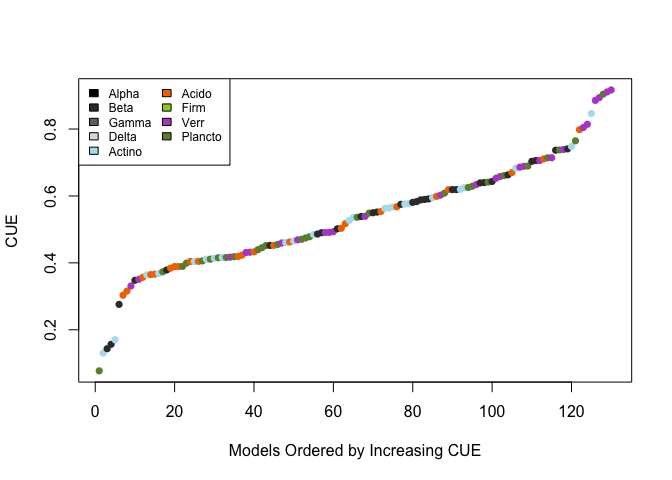

# 2a1

### **Phylogenetic Analyses**

Unconstrained CUE was analyzed for a phylogenetic signal. K values of 1 correspond to a Brownian motion process, which implies some degree of phylogenetic signal or conservatism. K values closer to zero correspond to a random or convergent pattern of evolution, while K values greater than 1 indicate strong phylogenetic signal and conservatism of traits.

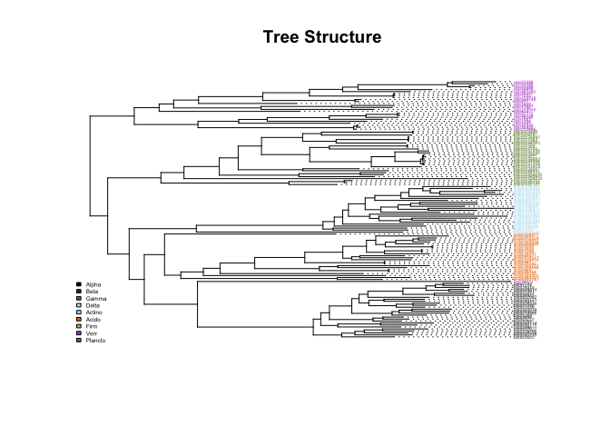

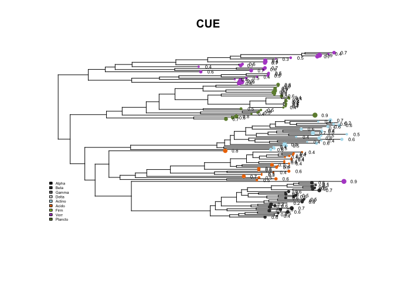

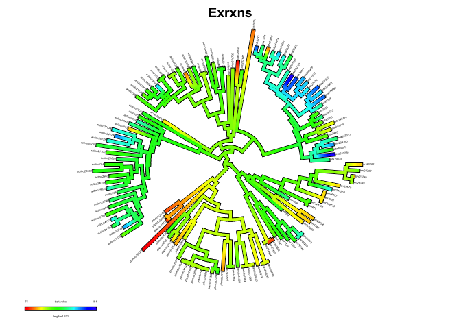

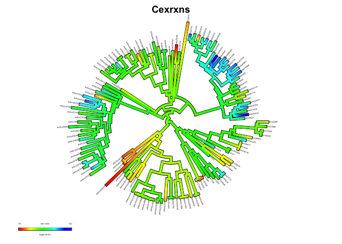

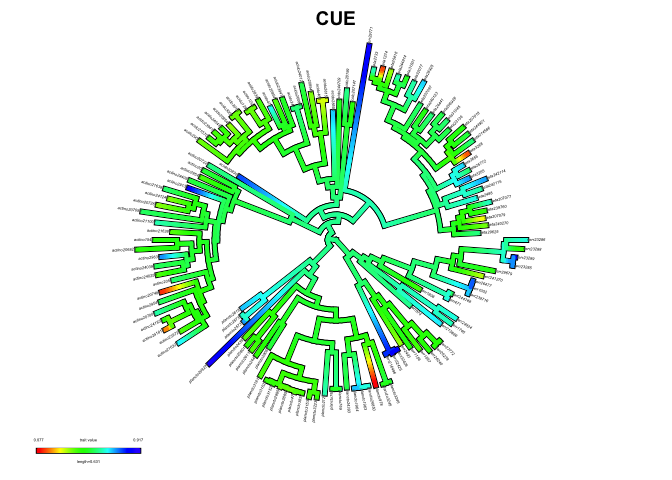

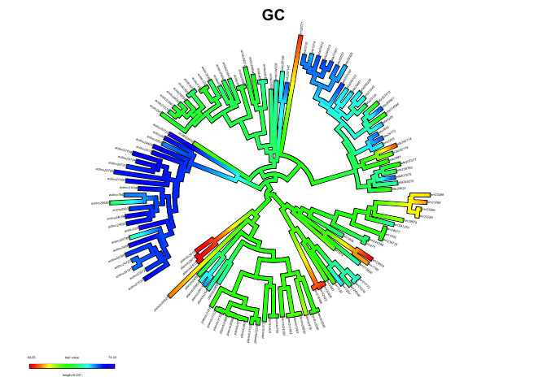

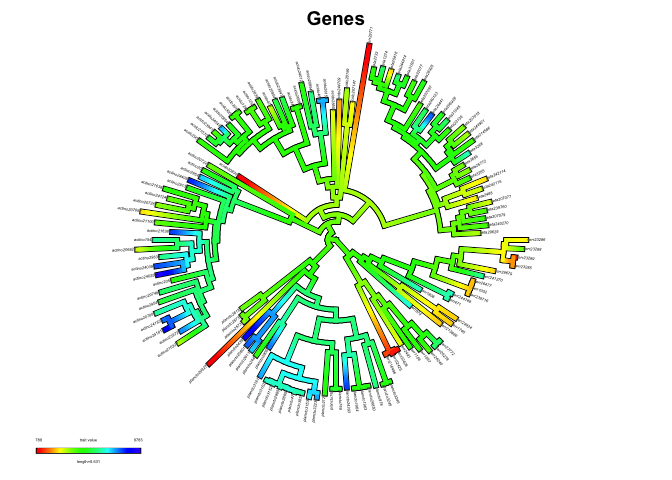

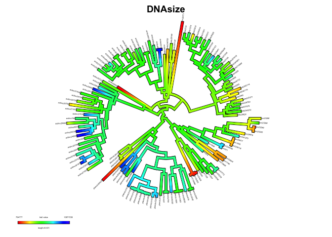

|  | K | PIC.variance.obs | PIC.variance.rnd.mean | PIC.variance.P | PIC.variance.Z |
| --- | --- | --- | --- | --- | --- |
| Exrxns | 0.1640496 | 2.051194e+03 | 3.681776e+04 | 0.001 | -2.5807560 |
| Cexrxns | 0.1725261 | 1.635154e+03 | 3.092815e+04 | 0.001 | -2.6985569 |
| CUE | 0.0377776 | 9.143651e-01 | 3.866792e+00 | 0.003 | -1.8840388 |
| GC | 1.2898714 | 7.349652e+01 | 1.006113e+04 | 0.001 | -2.7610550 |
| Contigs | 0.1758305 | 4.540426e+06 | 1.011696e+08 | 0.008 | -0.7268392 |
| Genes | 0.3146108 | 1.591306e+07 | 5.702364e+08 | 0.001 | -2.5990916 |
| DNAsize | 0.5020087 | 1.307122e+13 | 7.391281e+14 | 0.001 | -2.6955093 |

Phylogenetic Independent Contrasts were used to test for relationships between CUE and genome traits.

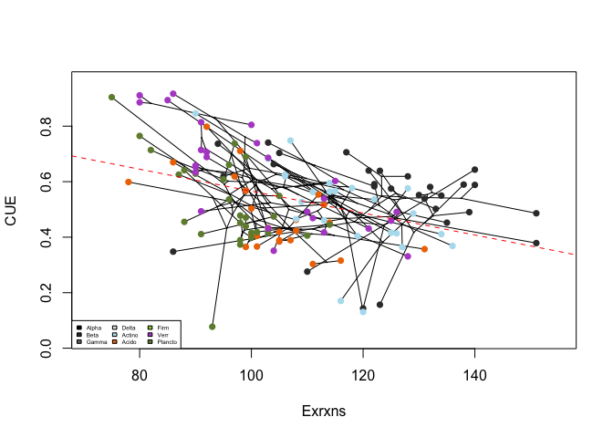

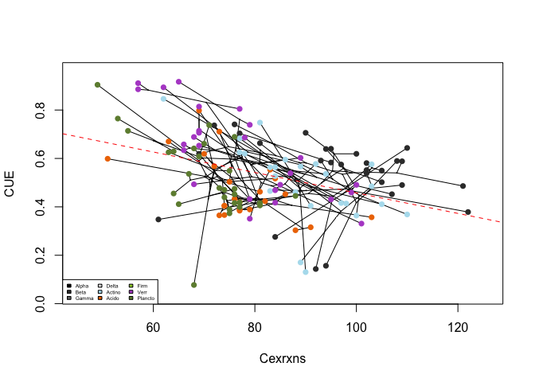

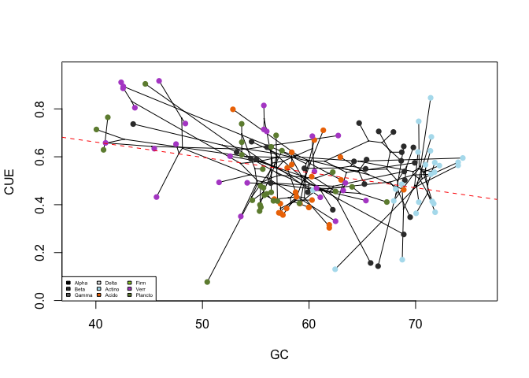

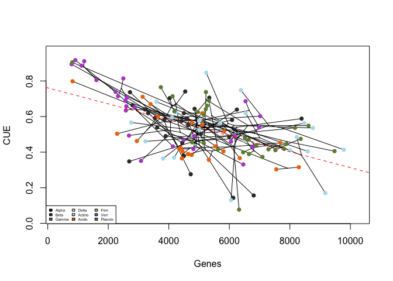

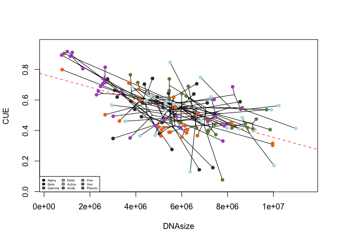

[output not shown]

# 2b

## **CONSTRAINED CUE**

For each model in the unconstrained environment, C-containing exchange reactions were classified according to the following hierarchy:

1. *Utilized*: reactions utilized by the model in the unconstrained environment.
> 2. *Essential*: reactions that are required for biomass production, identified as reactions that result in no biomass production when availability is set to zero.
> > 3. *Constraining*: reactions that biomass production responds to the availability of, i.e. reactions needed at more than a low threshold.

The uptake kinetics of the most common *constraining* reactions across models were analyzed. The availability of *constraining* reactions was then set to the concentration resulting in (a) 1/2 and (b) 1/4 of maximum biomass and CUE was recalculated.

# 2b1

### Uptake Kinetics

**Km and Vmax for Constraining Lists** *Fitting MM Models to Kinetics Data*

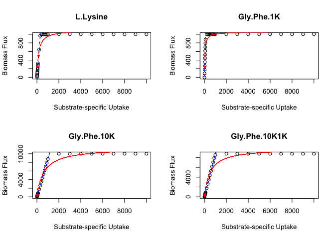

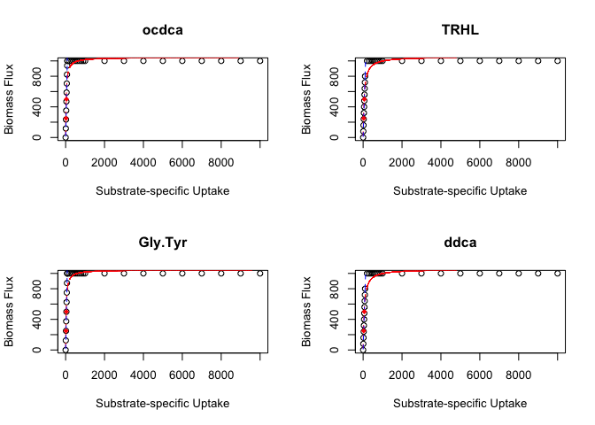

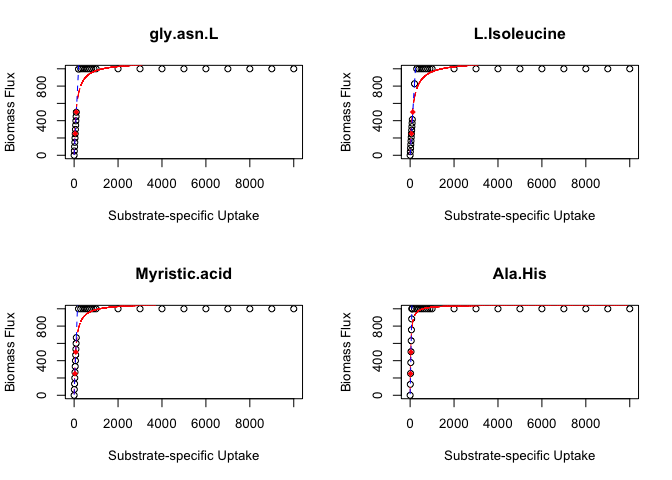

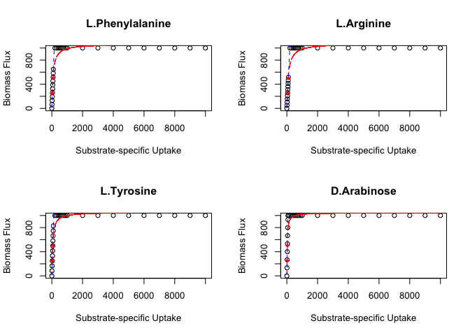

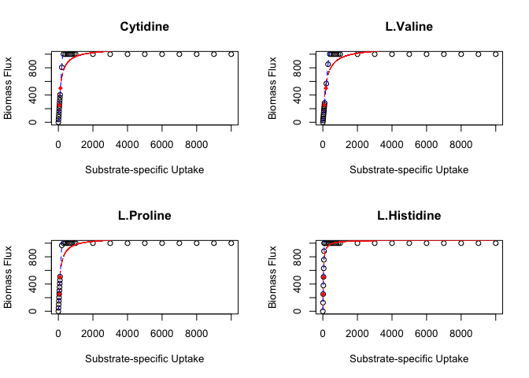

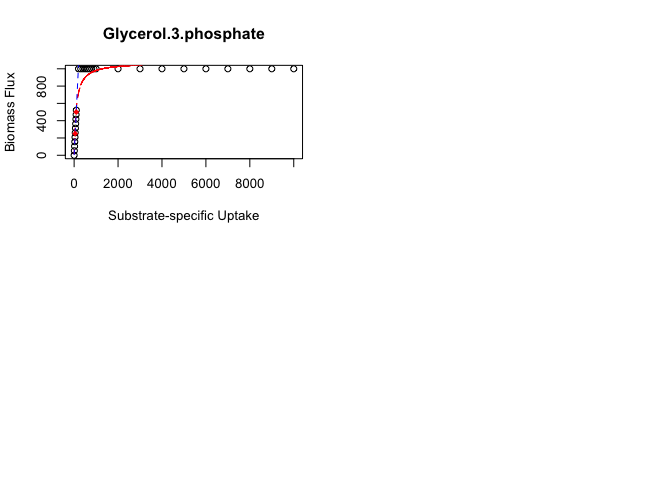

|  | uptake | L.Lysine | Gly.Phe.1K | Gly.Phe.10K | Gly.Phe.10K1K | ocdca | TRHL | Gly.Tyr | ddca | gly.asn.L | L.Isoleucine | Myristic.acid | Ala.His | L.Phenylalanine | L.Arginine | L.Tyrosine | D.Arabinose | Cytidine | L.Valine | L.Proline | L.Histidine | Glycerol.3.phosphate |
| --- | --- | --- | --- | --- | --- | --- | --- | --- | --- | --- | --- | --- | --- | --- | --- | --- | --- | --- | --- | --- | --- | --- |
| Km | NA | 155.1838328 | 50.4380138 | 6.378709e+02 | 514.564269 | 30.9441102 | 58.63531 | 28.0279135 | 58.63531 | 103.470412 | 125.531434 | 75.7168209 | 27.6516428 | 78.5264815 | 99.88237 | 55.45183 | 25.5975707 | 128.4957229 | 173.4981942 | 102.244632 | 27.6516428 | 99.045680 |
| Vm | NA | 1097.0794735 | 1053.1013772 | 1.136925e+04 | 9876.940300 | 1047.5678450 | 1056.66670 | 1046.9682062 | 1056.66670 | 1079.640287 | 1087.261558 | 1065.2770580 | 1046.8203125 | 1066.7497918 | 1077.89557 | 1055.20884 | 1046.0672293 | 1088.3203816 | 1100.9812684 | 1078.429742 | 1046.8203125 | 1077.465721 |
| lm-intercept | NA | -0.0000267 | 0.0000045 | 1.444028e-01 | 12.425781 | -0.0000044 | 0.00000 | 0.0000044 | 0.00000 | 0.000014 | -0.000027 | -0.0000045 | -0.0000167 | 0.0000091 | 0.00000 | 0.00000 | -0.0000167 | 0.0000054 | -0.0000076 | 9.087836 | -0.0000167 | 0.000000 |
| lm-slope | NA | 3.2211451 | 8.7803970 | 8.779215e+00 | 8.695916 | 11.7392473 | 7.99661 | 12.4926327 | 7.99661 | 4.979316 | 4.135675 | 6.6638419 | 12.6161319 | 6.4716755 | 5.17069 | 8.28661 | 13.3276840 | 4.0328230 | 2.8390284 | 4.875667 | 12.6161319 | 5.217443 |
| uptake at 500 | NA | 155.2243107 | 56.9450328 | 5.693625e+01 | 56.069331 | 42.5921688 | 62.52650 | 40.0235890 | 62.52650 | 100.415406 | 120.899252 | 75.0317927 | 39.6318000 | 77.2597443 | 96.69889 | 60.33830 | 37.5158966 | 123.9826288 | 176.1165937 | 100.686157 | 39.6318000 | 95.832379 |
| uptake at 250 | NA | 77.6121595 | 28.4725162 | 2.845990e+01 | 27.320205 | 21.2960846 | 31.26325 | 20.0117943 | 31.26325 | 50.207701 | 60.449629 | 37.5158967 | 19.8159007 | 38.6298715 | 48.34945 | 30.16915 | 18.7579489 | 61.9913137 | 88.0582982 | 49.411121 | 19.8159007 | 47.916189 |